# R5.01 - Environnement économique : Économie des inégalités

Chapitre 5: les inégalités économiques dans le monde et en France

Thomas Delcey

thomas.delcey@ube.fr

Université de Bourgogne Europe

### Le problème du chapitre

**L’état des inégalités dans le monde et en France**

Dans le chapitre 4, nous avons examiné les indicateurs classiques des inégalités économiques (indice de Gini, déciles et centiles de revenu, courbe de Lorenz, etc.). Concentrons-nous maintenant sur l’évolution récente des inégalités à l’échelle mondiale et nationale.

Dans ce chapitre, nous allons notamment chercher à comprendre comment la croissance mondiale a été répartie entre les différentes populations.

### La courbe de l’éléphant

**Quel groupe de la population mondiale a le plus bénéficié de la croissance économique ?**

- L’abscisse représente les centiles de la population mondiale ;
- L’ordonnée indique le taux de variation du revenu réel entre 1988 et 2008.
- La ligne rouge est la moyenne mondiale.

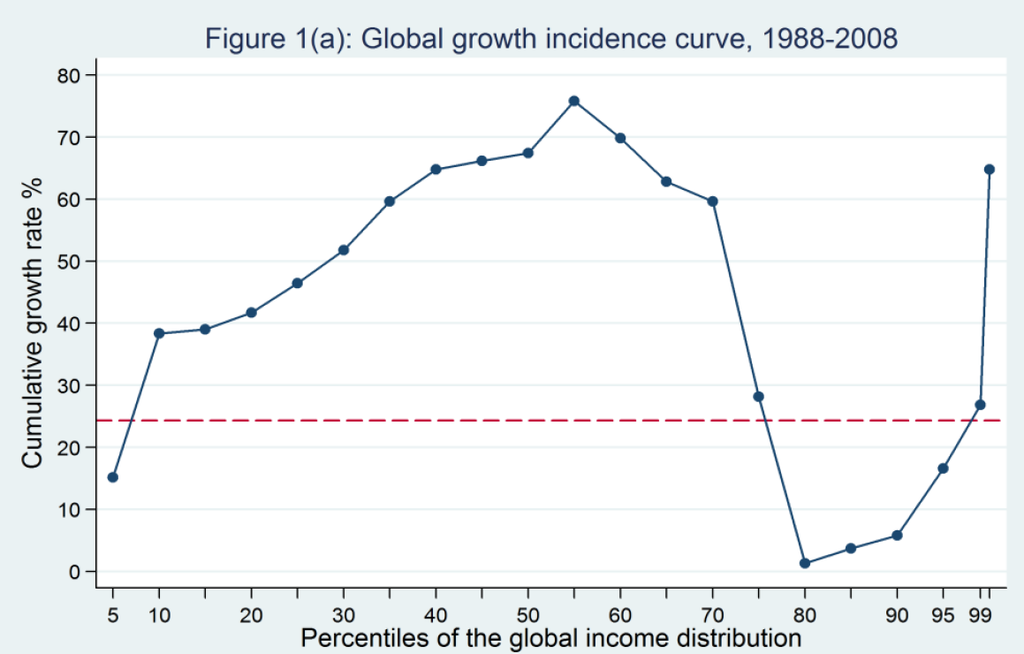

La courbe originale de Lakner et Milanovic (2016)

### La courbe de l’éléphant actualisée (1980-2023)

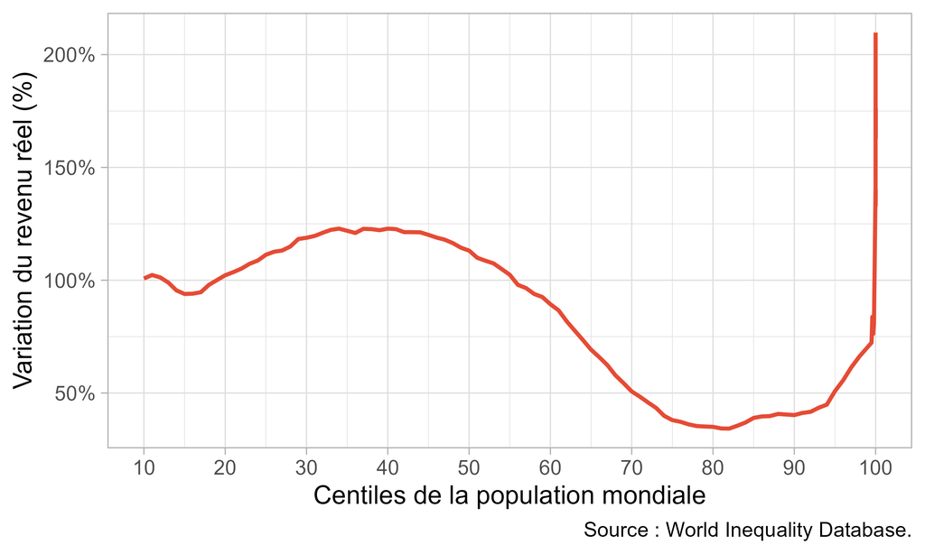

La courbe de l’éléphant actualisée avec les données du WID.world (1980-2023)

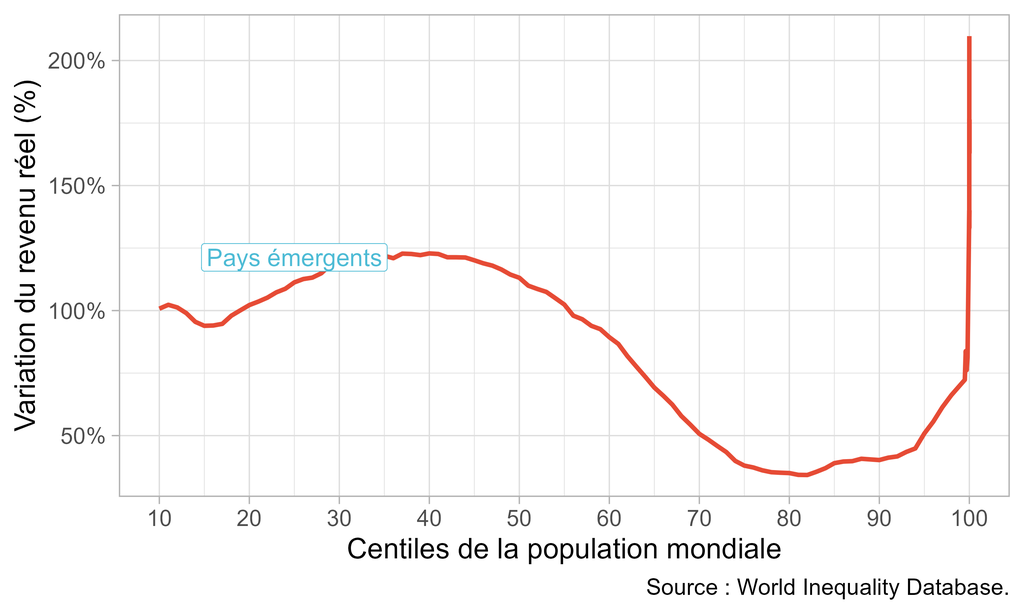

La courbe de l’éléphant actualisée avec les données du WID.world (1980-2023)

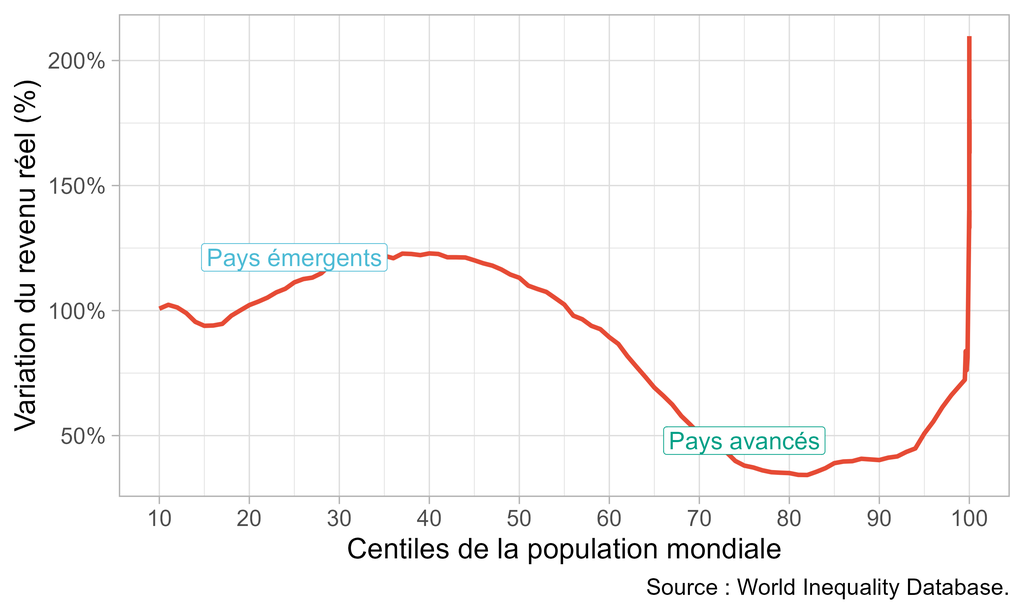

La courbe de l’éléphant actualisée avec les données du WID.world (1980-2023)

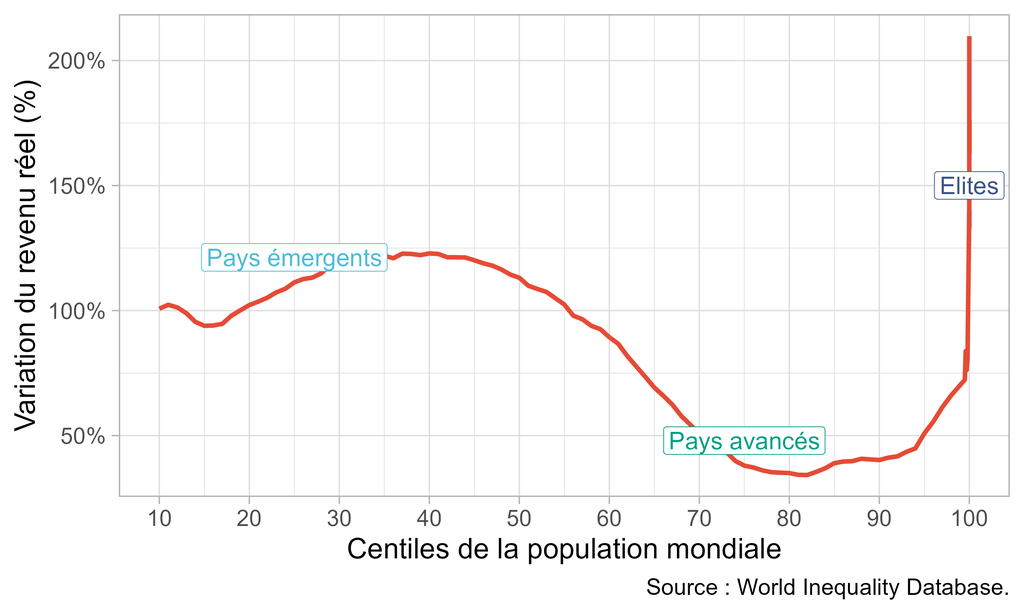

La courbe de l’éléphant actualisée avec les données du WID.world (1980-2023)